# QTL mapping: binomial GLM on the 5-fold union sites

XSun

2026-07-31

```r
library(data.table)
library(ggplot2)
library(qvalue)

knitr::opts_chunk$set(
  echo = TRUE, warning = FALSE, message = FALSE,
  fig.align = "center", fig.width = 10, fig.height = 6
)

PROJECT_DIR <- "/project/xinhe/xsun/pumseq"
RES <- file.path(PROJECT_DIR, "pumseq_processed/psi_qtl/qtl_binomial/lrt_results_merged")
WINDOWS_KB <- c(5, 20, 50, 100)
PC_COUNTS  <- c(0, 3, 5, 7, 10, 15, 20)
```

# Introduction

This page summarizes cis-QTL mapping for pseudouridylation (%pU) using the **binomial GLM** count model on the **5-fold union** sites (called in >= 1 fold; **12,416 sites**), across the **50 genotyped cell lines**. Unlike the linear tensorQTL approach — which builds a `treated - input` phenotype that is floored and quantile-normalized — the count model works directly on the raw converted-read counts, so no flooring or normalization is needed. The model and significance procedure are written up on the model page.

# 1. Phenotype: raw counts, modeled as binomial

For each site and cell line the phenotype is the pair of counts `y = C` (converted reads = %pU signal) out of `n = C + T` (read depth), extracted per cell line at the union sites. These enter the model directly as

$$y_i \mid p_i \sim \text{Binomial}(n_i, p_i), \qquad
\text{logit}(p_i) = \beta_0 + \beta_g G_i + z_i^\top\gamma .$$

Depth `n_i` is the binomial trial count, so low-coverage observations automatically carry less weight — there is no flooring, imputation, or quantile normalization step.

```r
COUNTS <- file.path(PROJECT_DIR, "pumseq_processed/psi_qtl/phenotype/fold5_union/counts")
C <- fread(file.path(COUNTS, "C_matrix.txt.gz"))
N <- fread(file.path(COUNTS, "N_matrix.txt.gz"))
cl <- setdiff(colnames(C), c("ref", "pos", "strand"))
Cm <- as.matrix(C[, ..cl]); Nm <- as.matrix(N[, ..cl])
pi_s <- rowSums(Cm) / rowSums(Nm)

knitr::kable(data.table(
  n_sites        = nrow(Cm),
  n_cell_lines   = length(cl),
  `median depth` = round(median(Nm), 1),
  `frac (site,CL) covered` = round(mean(Nm > 0), 3),
  `median site %pU` = round(median(pi_s, na.rm = TRUE), 3)
), caption = "5-fold union phenotype: per-cell-line converted counts C and depth N")
```

5-fold union phenotype: per-cell-line converted counts C and depth N

| n_sites | n_cell_lines | median depth | frac (site,CL) covered | median site %pU |
| --- | --- | --- | --- | --- |
| 12416 | 50 | 9 | 0.932 | 0.05 |

The pooled per-site modification rate is low (median ~5%), as expected for pseudouridylation — which is why the covariate transform below uses a site-specific pseudocount rather than a fixed one.

# 2. Covariates: M-value phenotype PCs

Following the IMAGE approach, covariates `z_i` are the top principal components of the **M-values** (log-odds of the modification rate). To avoid shrinking every site toward 50% (a fixed 1:1 pseudocount would), we use a **site-specific pseudocount** `(pi_s, 1 - pi_s)`, so each site is shrunk toward its own mean rate:

$$M_{si} = \log_2\frac{y_{si} + \pi_s}{\,n_{si} - y_{si} + (1-\pi_s)\,},
\qquad \pi_s = \frac{\sum_i y_{si}}{\sum_i n_{si}} .$$

Each site is standardized, PCA is taken across cell lines, and the top `k` PC scores are used as covariates. The number of PCs `k` is swept (below).

# 3. QTL mapping approach

For each (site, cis-SNP) pair the genotype effect `beta_g` is tested with a **likelihood-ratio test (LRT)**: fit the full model (with the cis-SNP) and the covariates-only null model, compare log-likelihoods. This is the more expensive per-SNP test (a full-model refit per cis-SNP, not one null fit per site), made feasible genome-wide by splitting the permutation scan across chromosomes (and, for a few unusually dense loci, further chunks) as parallel SLURM jobs — see the model page for why the LRT is used. Significance follows the standard human cis-QTL procedure:

1. **Per-SNP nominal p** from the LRT.
2. **Within-site correction** — the FastQTL/tensorQTL **permutation beta-approximation**: permute the phenotype 1000x, fit a Beta distribution to the null min-p, read off one adjusted p per site.
3. **Across-site correction** — **BH-FDR** (and q-values) over the per-site p.

Two things are swept:

- **Covariate PCs**: 0 (intercept-only, no phenotype-PC covariates), 3, 5, 7, 10, 15, 20.
- **cis-window**: 5 kb, 20 kb, 50 kb, 100 kb.

That is a 7 x 4 grid, each cell a separate scan.

# 4. Results: QTL sites by PC count and window size

```r
read_scan <- function(w, k) {
  f <- file.path(RES, sprintf("scan_lrt_w%dkb_pc%d.txt.gz", w, k))
  if (!file.exists(f)) return(NULL)
  d <- fread(f); d[, `:=`(window_kb = w, n_pcs = k)]; d
}
grid   <- CJ(w = WINDOWS_KB, k = PC_COUNTS)
scans  <- rbindlist(mapply(read_scan, grid$w, grid$k, SIMPLIFY = FALSE),
                    use.names = TRUE, fill = TRUE)

summary_tbl <- scans[, .(
  n_tested   = .N,
  qtl_FDR05  = sum(fdr < 0.05, na.rm = TRUE),
  qtl_FDR10  = sum(fdr < 0.10, na.rm = TRUE)
), by = .(window_kb, n_pcs)][order(window_kb, n_pcs)]
summary_tbl[, window_lab := factor(paste0(window_kb, "kb"),
                                   levels = paste0(WINDOWS_KB, "kb"))]

knitr::kable(dcast(summary_tbl, window_kb ~ n_pcs, value.var = "qtl_FDR05"),
             caption = "QTL sites (FDR<0.05): rows = cis-window (kb), columns = number of PCs")
```

QTL sites (FDR<0.05): rows = cis-window (kb), columns = number of PCs

| window_kb | 0 | 3 | 5 | 7 | 10 | 15 | 20 |
| --- | --- | --- | --- | --- | --- | --- | --- |
| 5 | 462 | 383 | 349 | 316 | 263 | 177 | 113 |
| 20 | 369 | 308 | 279 | 260 | 223 | 164 | 105 |
| 50 | 322 | 285 | 262 | 246 | 209 | 144 | 94 |
| 100 | 297 | 263 | 246 | 223 | 194 | 135 | 84 |

```r
ggplot(summary_tbl, aes(x = n_pcs, y = qtl_FDR05, color = window_lab)) +
  geom_line() + geom_point(size = 2) +
  scale_x_continuous(breaks = PC_COUNTS) +
  labs(x = "Number of covariate PCs", y = "QTL sites (FDR<0.05)", color = "cis-window",
       title = "QTL sites vs. number of covariate PCs, by cis-window size") +
  theme_bw(base_size = 13)
```

[figure not shown]

```r
ggplot(summary_tbl, aes(x = factor(n_pcs, levels = PC_COUNTS), y = window_lab, fill = qtl_FDR05)) +
  geom_tile() +
  geom_text(aes(label = qtl_FDR05), size = 3.8) +
  scale_fill_gradient(low = "white", high = "firebrick") +
  labs(x = "Number of covariate PCs", y = "cis-window size", fill = "QTL sites\n(FDR<0.05)",
       title = "QTL sites (FDR<0.05) by window size x PC count") +
  theme_bw(base_size = 13)
```

[figure not shown]

# 5. Calibration check: the binomial is anti-conservative even under the LRT

We permute the phenotype and covariates together across the 50 cell lines (breaking the genotype link, keeping phenotype-covariate pairing; genotype stays fixed at its true per-individual values), 5 seeds, and check whether the nominal p-values are Uniform(0,1) — via the genomic-inflation factor `lambda` (median chi-square / 0.455; should be ~1 under a calibrated null) and a QQ-plot. Same negative-control permutation as the linear model. Run at **5 kb, 3 PCs** (the smallest PC count calibration was checked at; k=0 has not been calibration-tested, so its higher raw discovery count above should be read with that caveat).

```r
CAL_LRT <- file.path(PROJECT_DIR, "pumseq_processed/psi_qtl/qtl_binomial/lrt_calibration")
lam_lrt <- fread(file.path(CAL_LRT, "calib_lrt_w5kb_pc3_lambda.txt"))
knitr::kable(lam_lrt, digits = 2,
             caption = "Genomic-inflation lambda (5kb, 3 PCs): real vs. 5 permuted nulls")
```

Genomic-inflation lambda (5kb, 3 PCs): real vs. 5 permuted nulls

| dataset | lambda |
| --- | --- |
| real | 5.55 |
| perm1 | 3.44 |
| perm2 | 2.93 |
| perm3 | 3.39 |
| perm4 | 3.43 |
| perm5 | 3.19 |

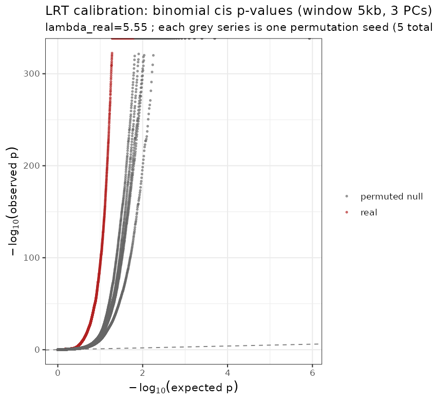

```r
cat(sprintf('<img src="%s" style="max-width:70%%;">',
            knitr::image_uri(file.path(CAL_LRT, "calib_lrt_w5kb_pc3_qq.png"))))
```

**Real data lambda=5.55, permuted-null lambda=~3.28** (range 2.93-3.44 across 5 seeds) — well above the ideal 1. This is not a numerical artifact of the test itself (the LRT compares two independently-computed log-likelihoods directly, with none of the boundary-adjacent failure modes a faster approximate test can have — see the model page); it reflects **real overdispersion the plain binomial model doesn’t account for**. A separate test for $H_0:\phi=0$ finds ~22% of sites significantly overdispersed (FDR<0.05) — see the beta-binomial page, which models this variance directly and calibrates much closer to 1 (permuted-null ~1.13-1.17).

Practical consequence: **more PCs will not fix this** (overdispersion is a variance mis-specification, not a mean confounder — the monotonic decline in QTL counts with more PCs in Section 4 reflects spent degrees of freedom, not improving calibration), and the per-site QTL *calls* above use the permutation beta-approximation (self-calibrating against this same inflation), so the FDR counts are more robust than the raw nominal lambda suggests — but the residual inflation here is the reason the beta-binomial model is worth treating as the more complete final model.